# PLAY Release 1.0: Surveys

## Purpose

This document summarizes the workflow for the PLAY 1.0 data release related to the non-MBCDI survey data.

## Setup

The user should authenticate to Databrary using `databraryapi::login_db()` prior to knitting this document.

```
## Login successful.
```

```
## [1] TRUE
```

Import helper functions and libraries

## Import

We read the CSV with the file name: “PLAY_release_1.0_non_MBCDI_data” stored in volume 1280 and session/folder 51539.

There are \(n=\) 81 sessions in the data file.

## Demographic data summaries

## QA status overall

| qa_group | Freq |
| --- | --- |
| PLAY_Gold | 62 |
| PLAY_Silver | 17 |

## Age group by QA status

|  | 12mo | 18mo | 24mo |
| --- | --- | --- | --- |
| PLAY_Gold | 27 | 16 | 19 |
| PLAY_Silver | 2 | 10 | 5 |

## Sex by age group

|  | 12mo | 18mo | 24mo |
| --- | --- | --- | --- |
| female | 18 | 14 | 7 |
| male | 12 | 12 | 18 |

## Race and ethnicity

|  | Hispanic or Latino | Not Hispanic or Latino |
| --- | --- | --- |
| Asian | 0 | 1 |
| Black or African American | 1 | 0 |
| More than one | 9 | 8 |
| Other | 2 | 2 |
| White | 5 | 53 |

## Spanish spoken to child

|  | FALSE | TRUE |
| --- | --- | --- |
| 12mo | 25 | 5 |
| 18mo | 24 | 2 |
| 24mo | 22 | 3 |

## Locomotor milestones

## Crawl onset

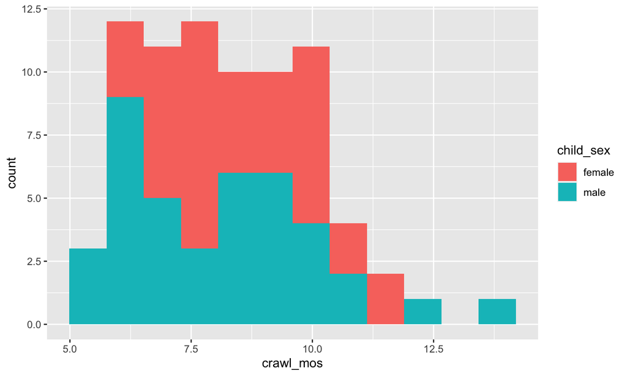

## Walk onset (KEA criteria)

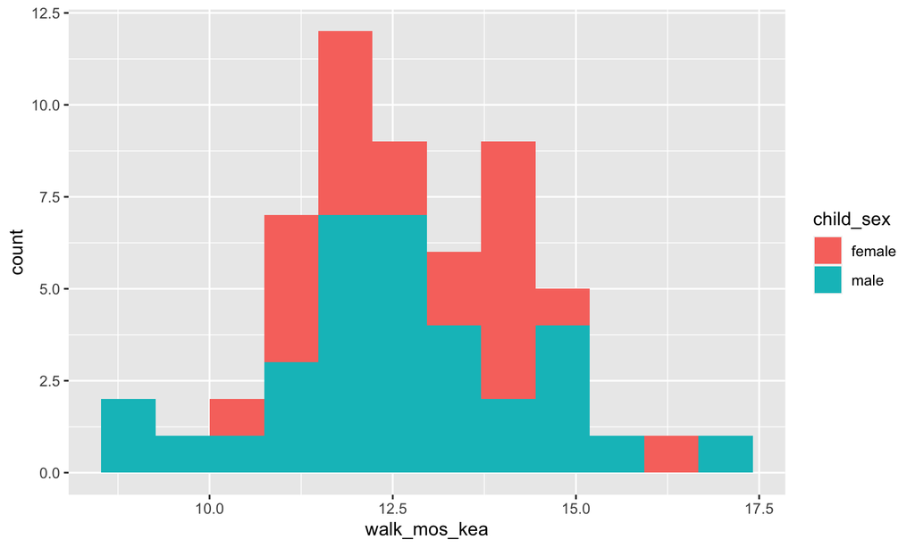

## Walk onset (WHO criteria)

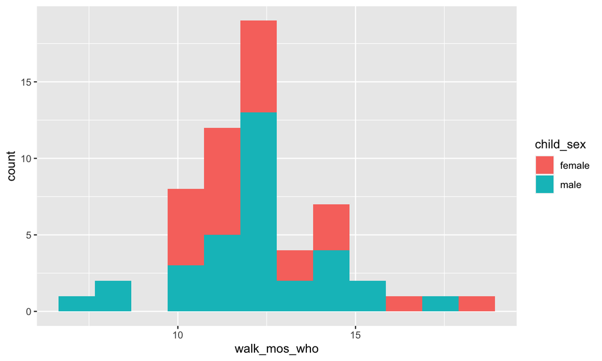

## Walk (KEA) by walk (WHO) onset

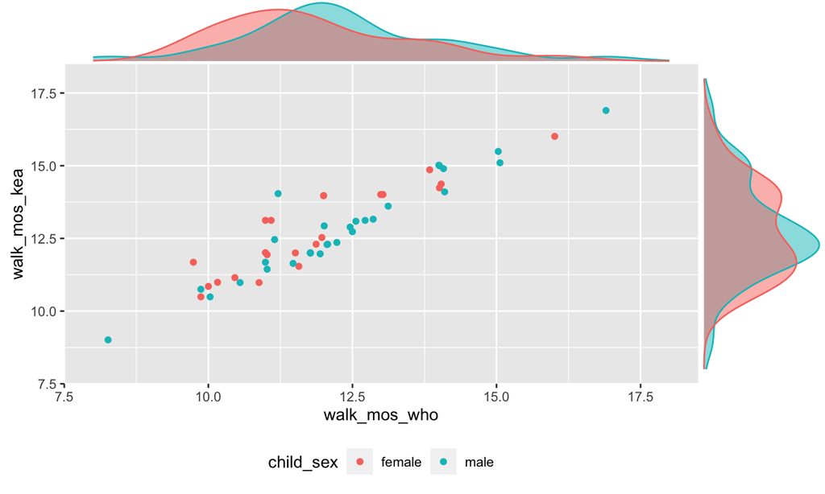

## Walk (KEA) by crawl onset

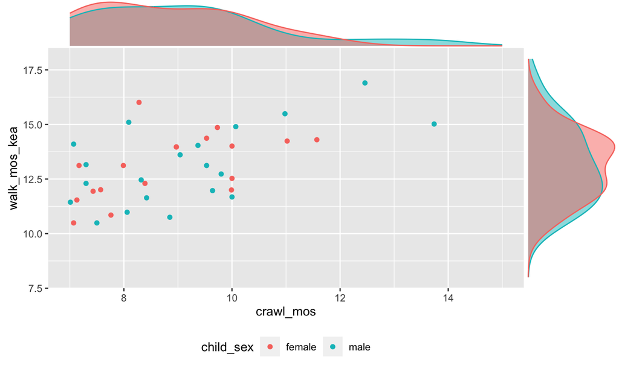

## PHQ-4

## Question…

> “*Over the last two weeks, how often have you been bothered by the following problems…*”

## “*…Feeling nervous, anxious, or on edge?*”

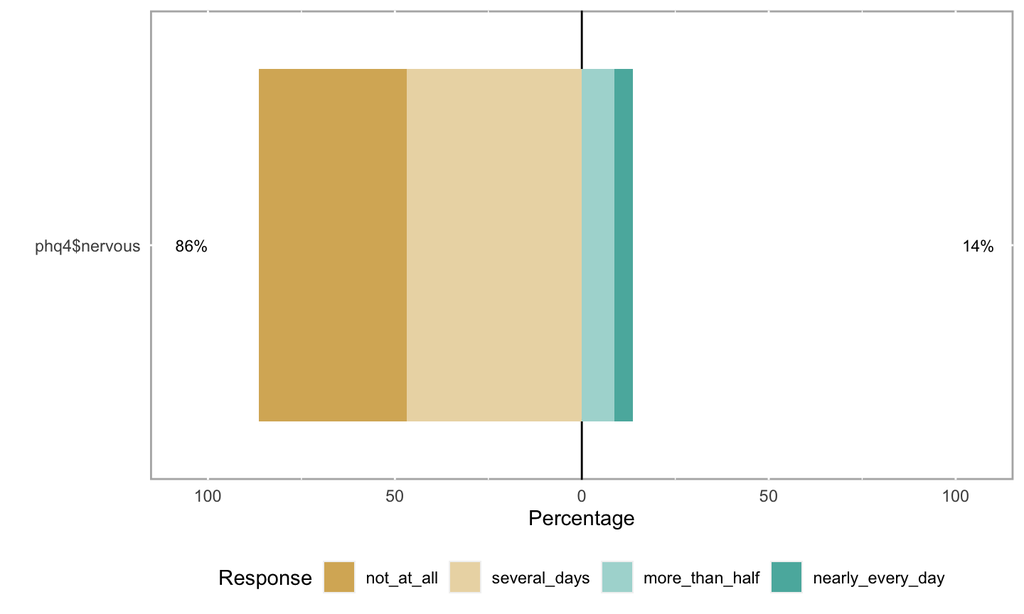

## “*…Not being able to stop or control worrying?*”

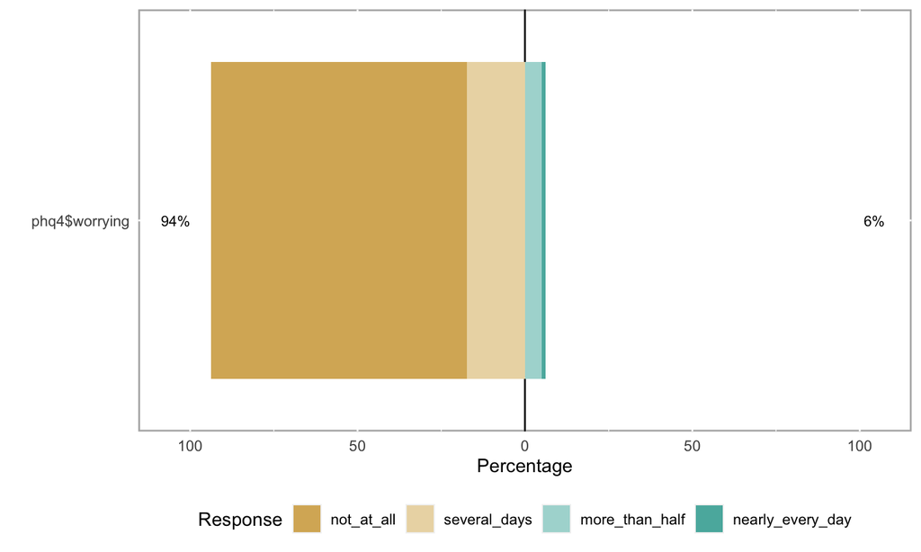

## “*…Little interest or pleasure in doing things?*”

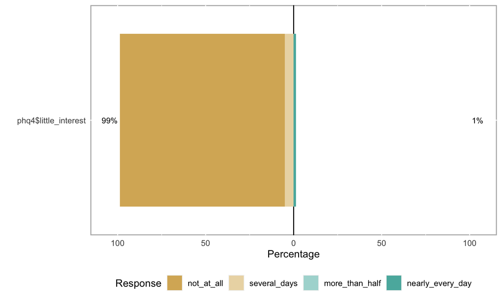

## “*…Feeling down, depressed, or hopeless?*”

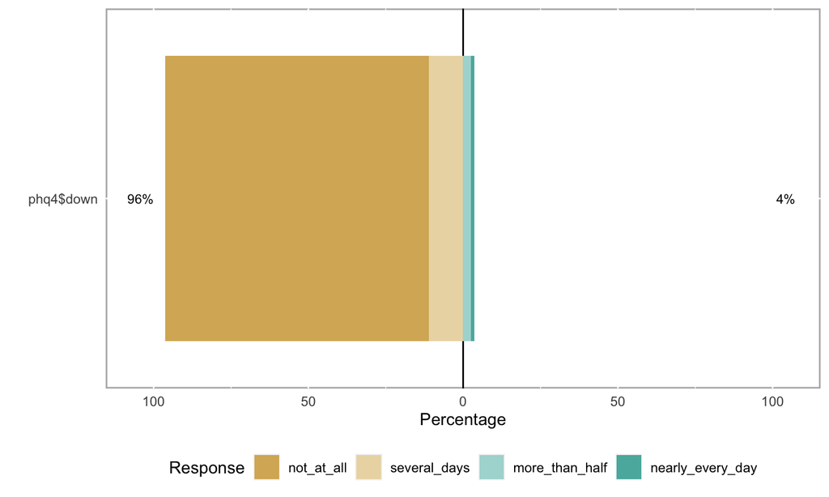

## Health

## Breastfeeding

|  | no | yes |
| --- | --- | --- |
| female | 0 | 39 |
| male | 3 | 39 |

## Solid foods introduced

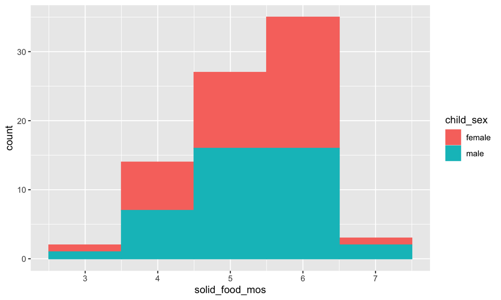

## Smoking/drinking

|  | no | yes |
| --- | --- | --- |
| no | 57 | 24 |

## Sleeping position

| child_sleeping_position | Freq |
| --- | --- |
| back | 77 |
| no_special_way | 1 |
| other | 1 |
| stomach_side | 2 |

## Child health rating

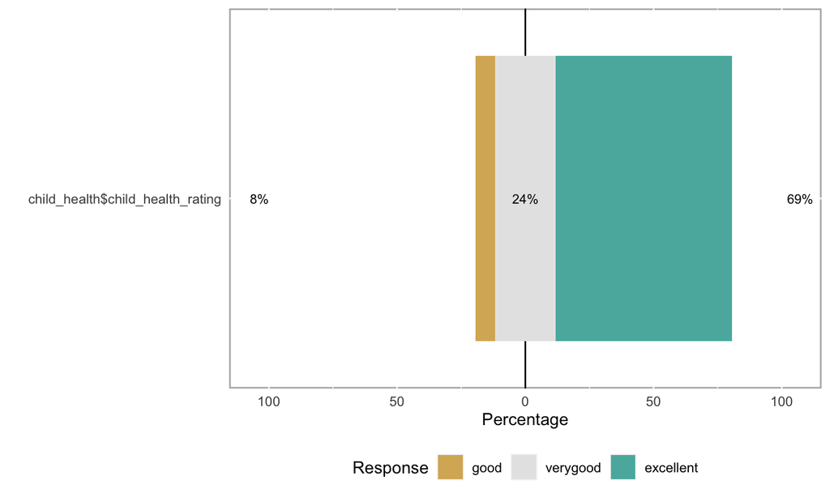

## See medical specialist

|  | no | yes |
| --- | --- | --- |
| 12mo | 10 | 20 |
| 18mo | 12 | 14 |
| 24mo | 11 | 14 |

## Recently vaccinated

|  | donotknow | no | yes |
| --- | --- | --- | --- |
| 12mo | 0 | 19 | 11 |
| 18mo | 1 | 20 | 5 |
| 24mo | 0 | 19 | 6 |

## Vision screen

|  | after_home | birth_hospital | both_hospital_home | do_not_know | no |
| --- | --- | --- | --- | --- | --- |
| 12mo | 5 | 9 | 1 | 2 | 13 |
| 18mo | 6 | 9 | 2 | 0 | 9 |
| 24mo | 5 | 5 | 0 | 3 | 12 |

## Hearing screen

|  | after_home | birth_hospital | both_hospital_home | no |
| --- | --- | --- | --- | --- |
| 12mo | 1 | 26 | 3 | 0 |
| 18mo | 3 | 18 | 4 | 1 |
| 24mo | 0 | 20 | 3 | 2 |

## Media use

## TV

Child use TV

|  | no | yes |
| --- | --- | --- |
| 12mo | 12 | 17 |
| 18mo | 4 | 22 |
| 24mo | 5 | 18 |

## Tablet

Child use tablet

|  | no | yes |
| --- | --- | --- |
| 12mo | 19 | 4 |
| 18mo | 13 | 7 |
| 24mo | 8 | 14 |

## Computer

Child use computer

|  | no | yes |
| --- | --- | --- |
| 12mo | 22 | 5 |
| 18mo | 19 | 5 |
| 24mo | 20 | 5 |

## Educational games

Child use educational games

|  | no | yes |
| --- | --- | --- |
| 12mo | 0 | 1 |
| 18mo | 3 | 1 |
| 24mo | 0 | 5 |

## Videogames

Child use videogames

|  | no |
| --- | --- |
| 12mo | 16 |
| 18mo | 12 |
| 24mo | 11 |

## Pets

## Pets at home/where live

|  | indoors |
| --- | --- |
| yes | 43 |

## Types of pets

[output not shown]

[output cut: 29 more lines]

## Typical Day

## Typical behavior

|  | 12mo | 18mo | 24mo |
| --- | --- | --- | --- |
| no | 3 | 5 | 0 |
| yes | 26 | 20 | 25 |

|  | PLAY_Gold | PLAY_Silver |
| --- | --- | --- |
| no | 5 | 3 |
| yes | 56 | 13 |

## Typical activities

|  | 12mo | 18mo | 24mo |
| --- | --- | --- | --- |
| no | 2 | 7 | 4 |
| yes | 27 | 19 | 21 |

|  | PLAY_Gold | PLAY_Silver |
| --- | --- | --- |
| no | 9 | 4 |
| yes | 52 | 13 |

## Typical night/morning

|  | 12mo | 18mo | 24mo |
| --- | --- | --- | --- |
| no | 8 | 4 | 4 |
| yes | 21 | 22 | 21 |

|  | PLAY_Gold | PLAY_Silver |
| --- | --- | --- |
| no | 13 | 3 |
| yes | 48 | 14 |

## Typical other than researcher presence

|  | 12mo | 18mo | 24mo |
| --- | --- | --- | --- |
| no | 5 | 4 | 3 |
| yes | 24 | 22 | 22 |

|  | PLAY_Gold | PLAY_Silver |
| --- | --- | --- |
| no | 11 | 1 |
| yes | 50 | 16 |

## Rothbart (ECBQ)

## **“In the last two weeks…”**

## 1. “When approached by an unfamiliar person in a public space (for example., the grocery store), how often did your child cling to a parent?”

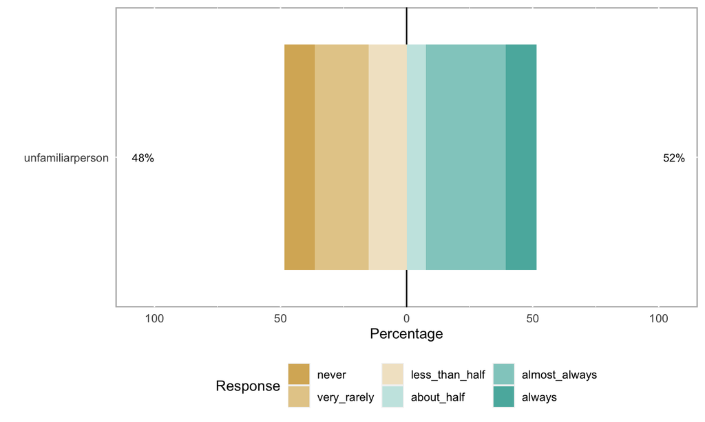

## 2. “While having trouble completing a task (e.g. building, drawing, dressing), how often did your child get easily irritated?”

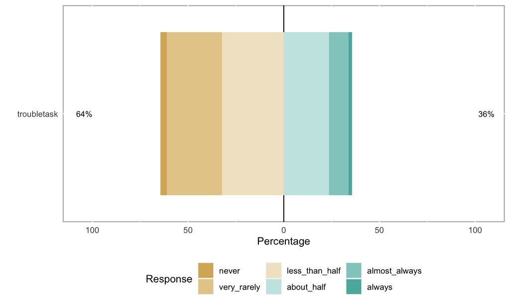

## 3. “When a familiar child came to your home, how often did your child seek out the company of the child?”

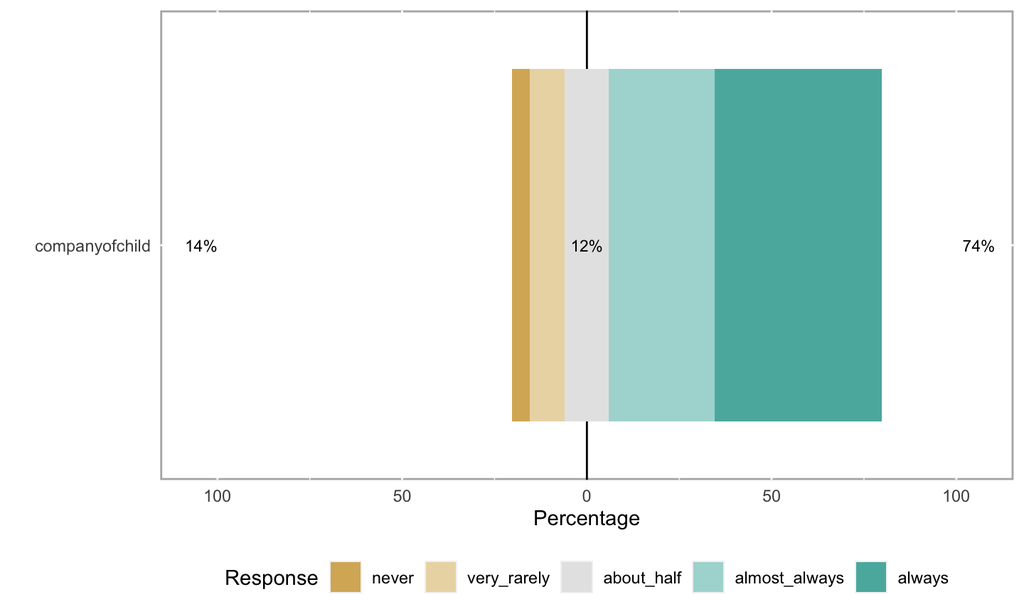

## 4. “When offered a choice of activities, how often did your child decide what to do very quickly and go for it?”

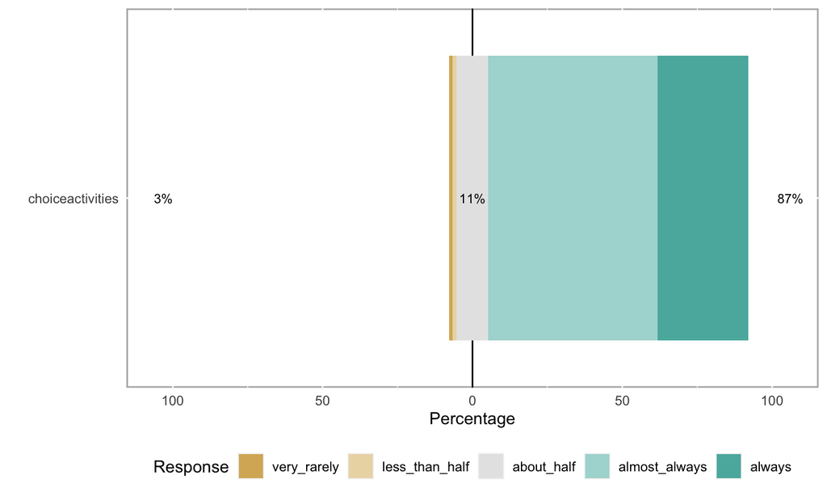

## 5. “During daily or evening quiet time with you and your child, how often did your child enjoy just being quietly sung to?”

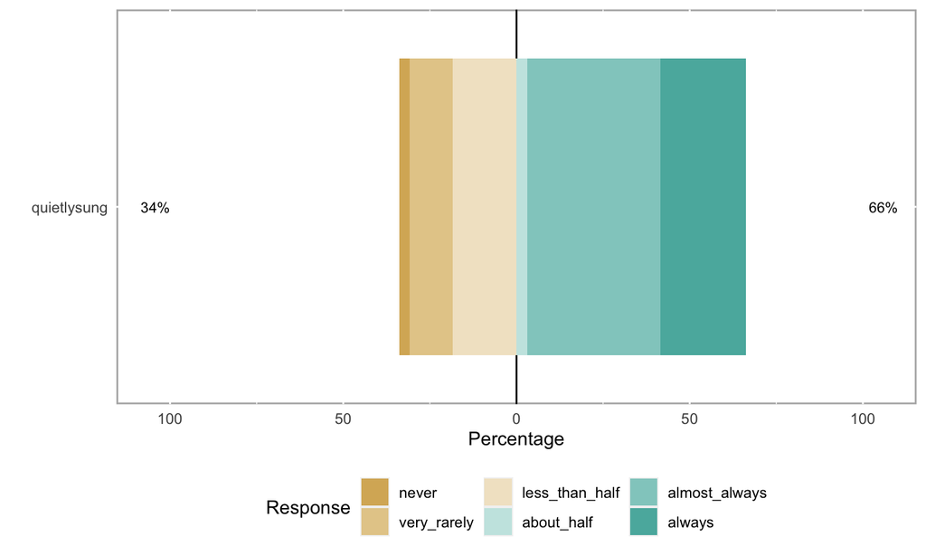

## 6. “While playing outdoors, how often did your child choose to take chances for the fun and excitement of it?”

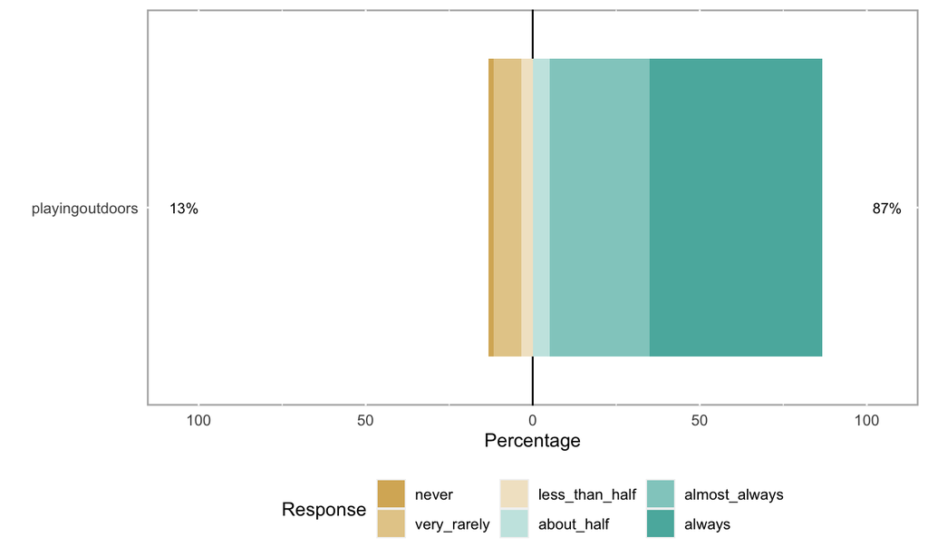

## 7. “While engaged in play with his/her favorite toy, how often did your child play for more than 10 minutes?”

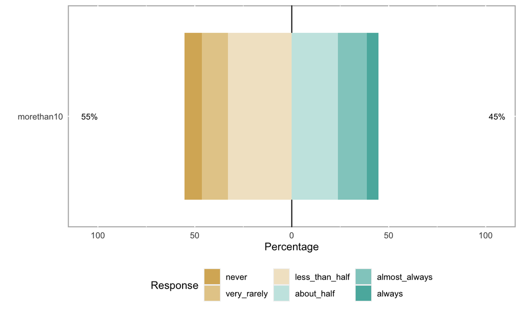

## 8. “While engaged in play with his/her favorite toy, how often did your child continue to play while *at the same time* responding to your remarks or questions?”

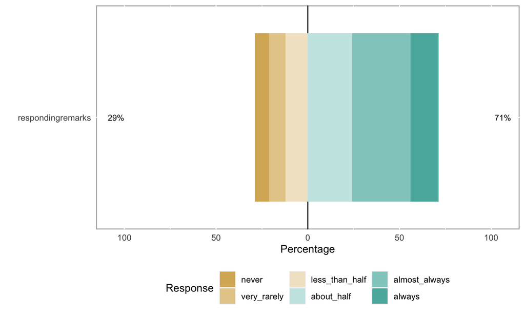

## 9. “When told that loved adults would visit, how often did your child get very excited?”

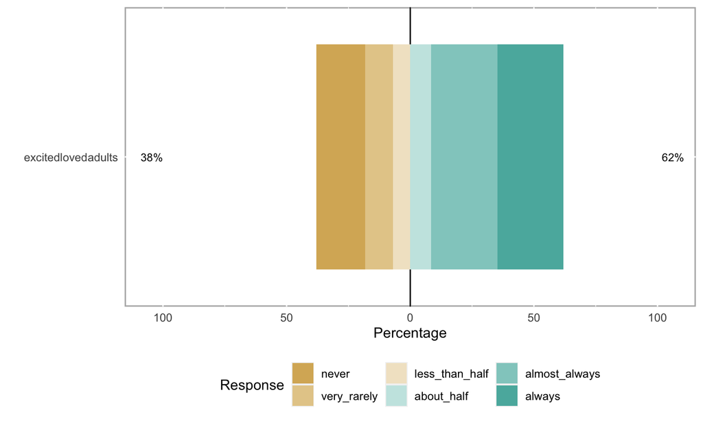

## 10. “During quiet activities, such as reading a story, how often did your child fiddle with his/her hair, clothing, etc.?”

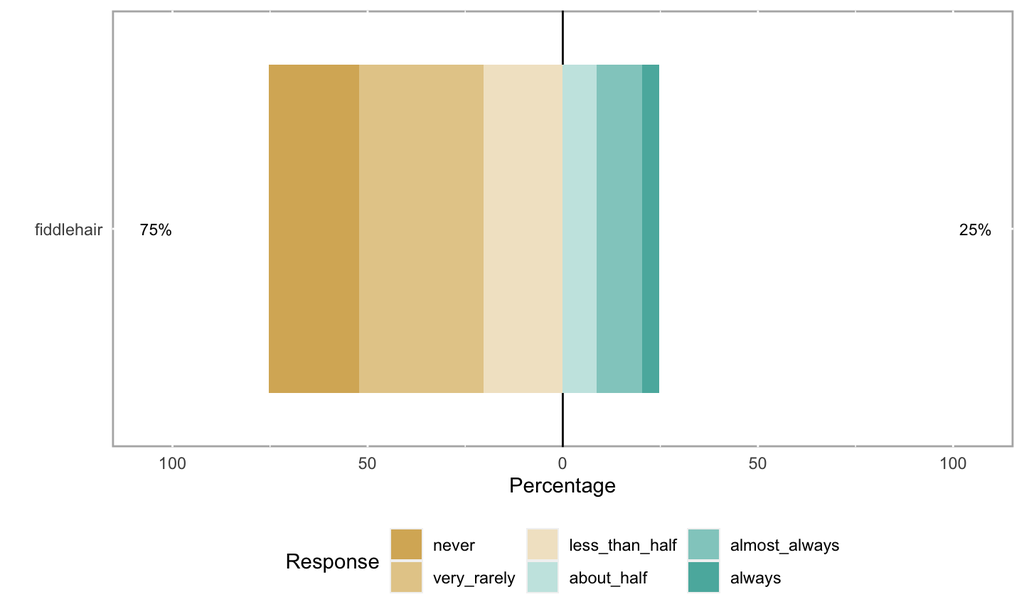

## 11. “While playing indoors, how often did your child like rough and rowdy games?”

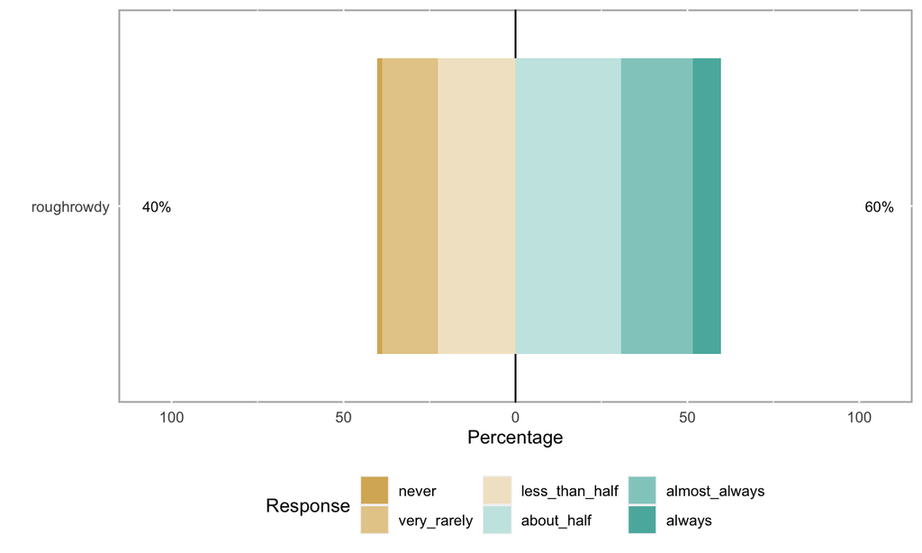

## 12. “When being gently rocked or hugged, how often did your child seem eager to get away?”

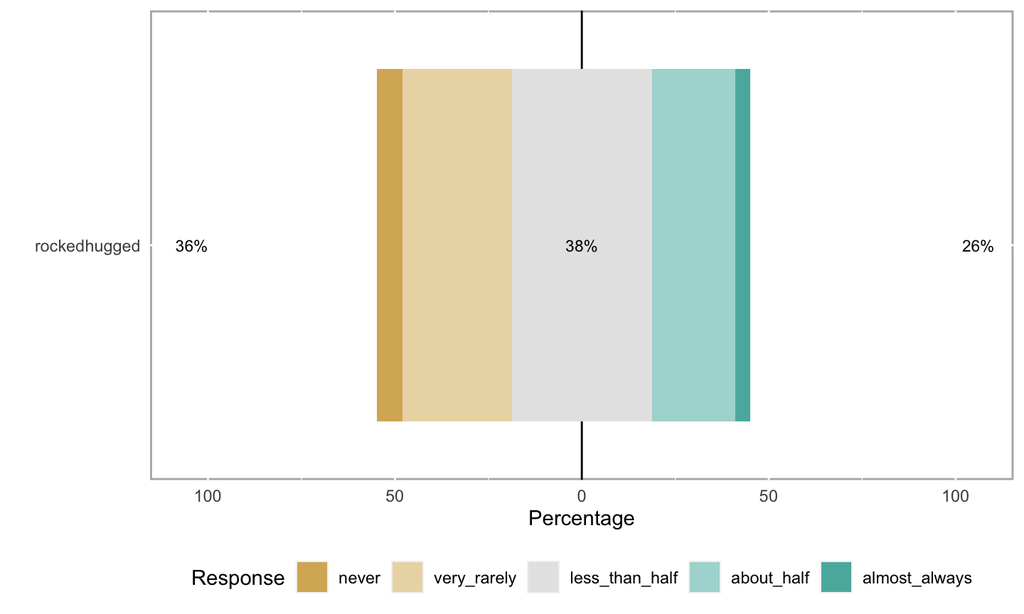

## 13. “When encountering a new activity, how often did your child get involved immediately?”

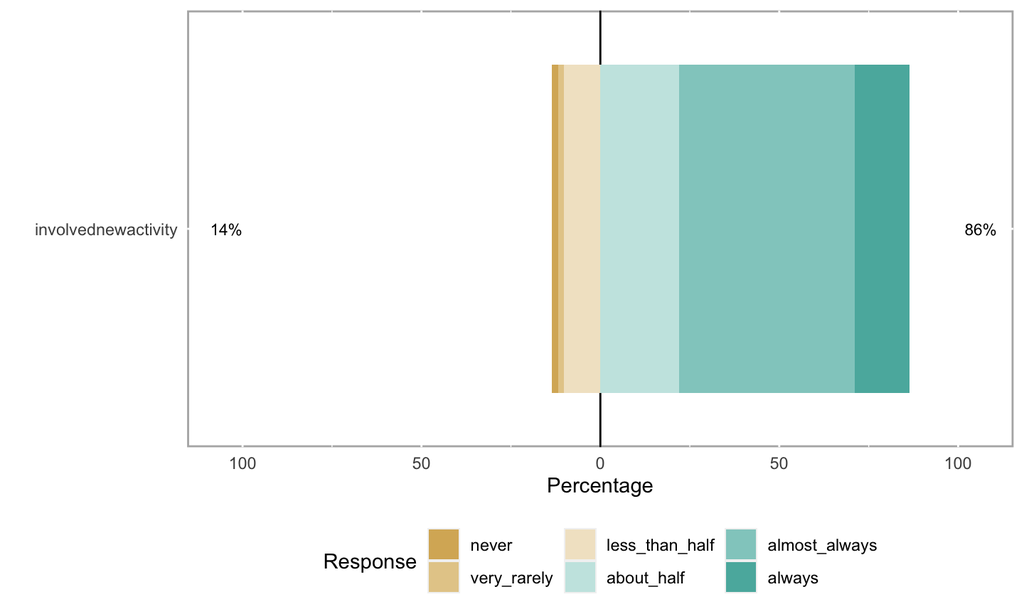

## 14. “When engaged in an activity requiring attention, such as building with blocks, how often did your child tire of the activity relatively quickly?”

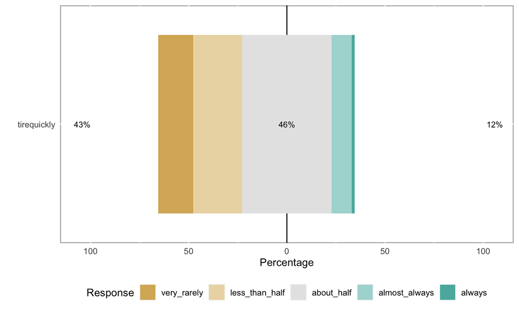

## 15. “During everyday activities, how often did your child pay attention to you right away when you called to him/her?”

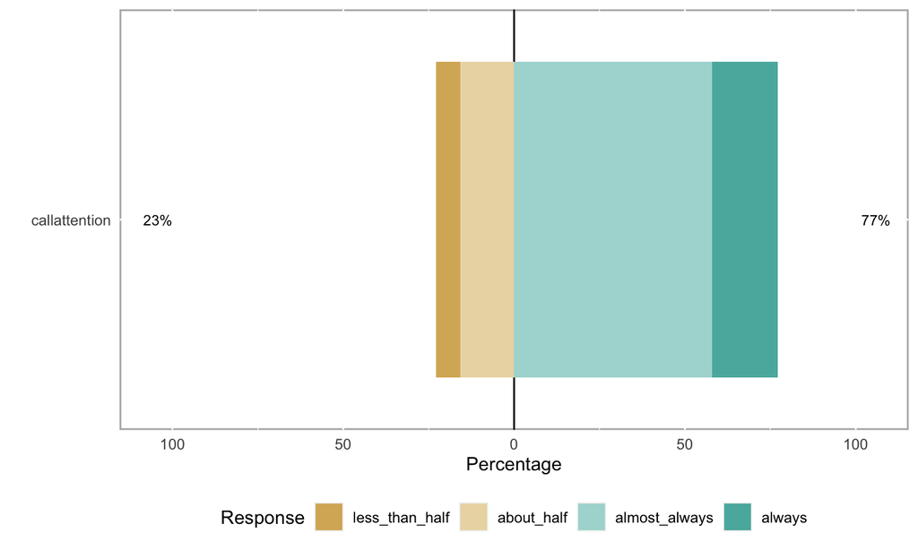

## 16. “During everyday activities, how often did your child seem to be irritated by tags in his/her clothes?”

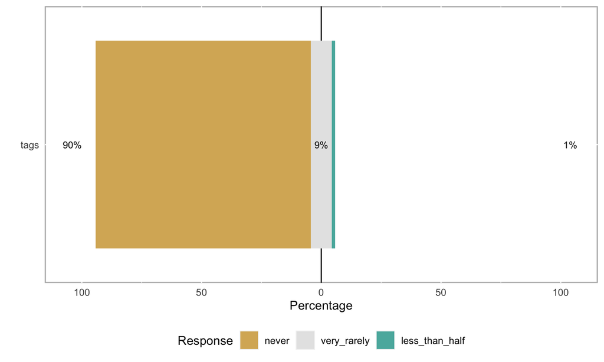

## 17. “During everyday activities, how often did your child become bothered by sound while in a noisy environment?”

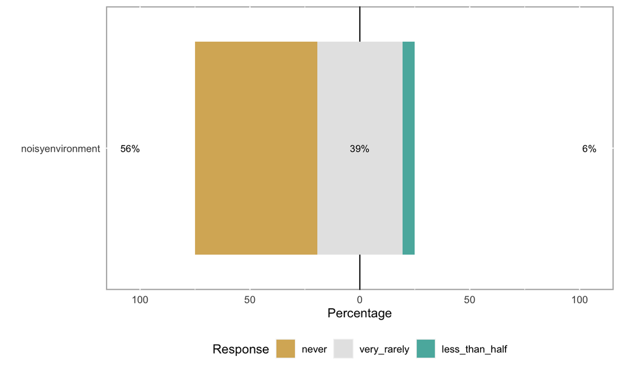

## 18. “During everyday activities, how often did your child seem full of energy, even in the evening?”

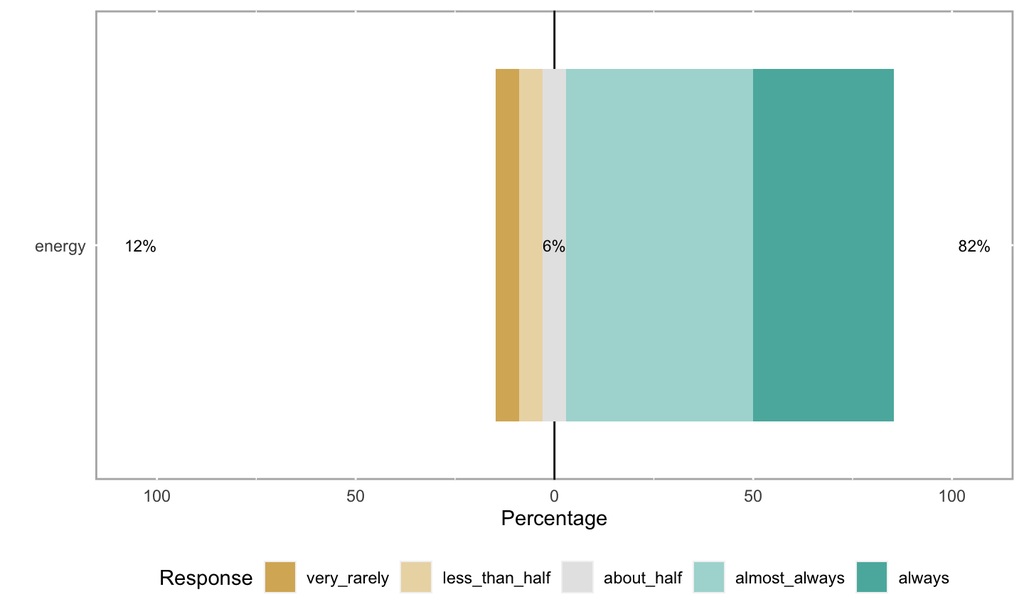

## 19. “While in a public place, how often did your child seem afraid or large, noisy vehicles?”

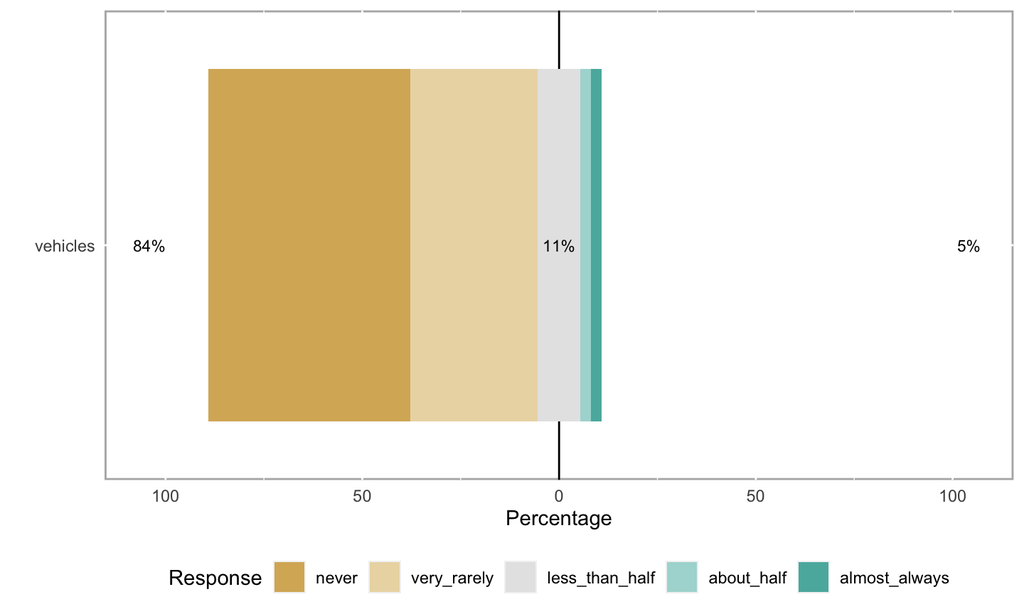

## 20. “When playing outdoors with other children, how often did your child seem to be one of the most active children?

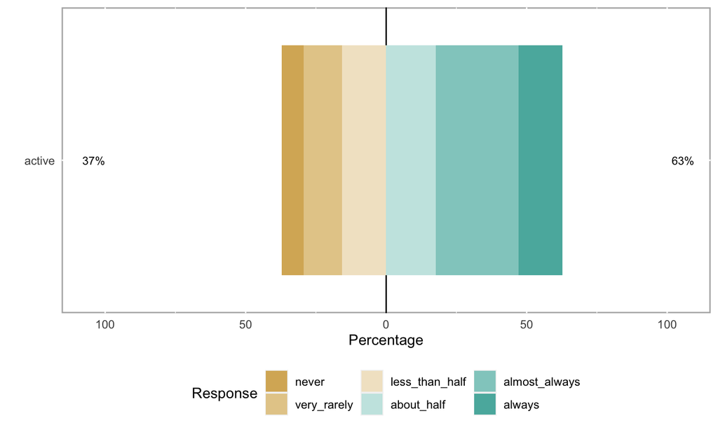

## 21. “When told”no”, how often did your child stop the forbidden activity?”

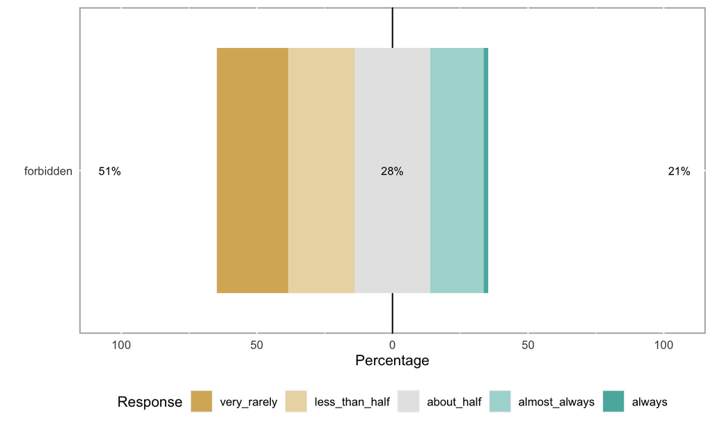